# Рост певцов хора

В 1979 году было опрошено 235 членов нью-йоркской ассоциации хорового пения, для каждого из них известен рост и регистр голоса. Меняется ли средний рост вместе с регистром?

```r
library(lattice)
```

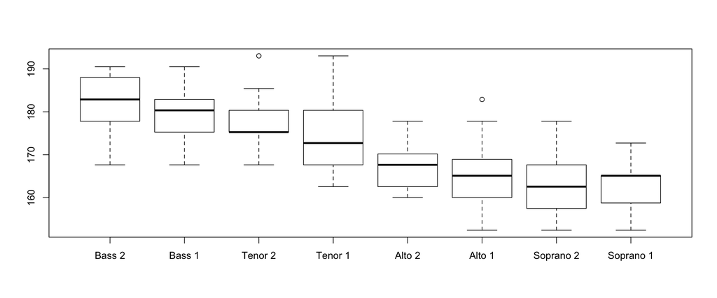

```r
singer$height <- singer$height * 2.54
boxplot(height~voice.part, data=singer)
```

```r
table(singer$voice.part)
```

```
##
##    Bass 2    Bass 1   Tenor 2   Tenor 1    Alto 2    Alto 1 Soprano 2
##        26        39        21        21        27        35        30
## Soprano 1
##        36
```

1. Воспользуйстесь непараметричеcким критерием Краскела-Уоллиса с помощью функции `kruskal.test` для признака `height` и фактора `voice.part`.

```r
kruskal.test(singer$height, singer$voice.part)
```

```
##
##  Kruskal-Wallis rank sum test
##
## data:  singer$height and singer$voice.part
## Kruskal-Wallis chi-squared = 141.84, df = 7, p-value < 2.2e-16
```

2. Для проверки однородности выборок из нормального распределения можно поступать следующим образом. Сначала проверить гипотезу о равенстве дисперсий (Бартлета) и в случае, если эта гипотеза принимается, воспользоваться нормальным однофакторным дисперсионным анализом для проверки гипотезы о равнестве всех средних.
- Проверьте гипотезу о равенстве дисперсий выборок, определяющихся значением фактора `voice.part` c помощью критерия Бартлета `bartlett.test`
- Проведите нормальный однофакторный дисперсионный анализ с помощью функции `aov` из стандартного пакета `stats`. Первым аргументом в `aov` нужно передать R формулу (хорошую справку можно найти с помощью команды `?formula`), где слева от знака `~` будет располагаться название значения признака (без кавычек), а справа - название анализируемого фактора. Изучите вывод функции `summary`, в которую передайте результат выполнения функции `aov`. Также рассмотрите вывод функции `model.tables` от того же объекта с параметром `type="means"` и с параметром `type="effects"`.

Критерий Бартлетта:

```r
bartlett.test(height~voice.part, data=singer)
```

```
##
##  Bartlett test of homogeneity of variances
##
## data:  height by voice.part
## Bartlett's K-squared = 11.736, df = 7, p-value = 0.1096
```

Нормальный однофакторный дисперсионный анализ:

```r
a1 <- aov(height~voice.part, data=singer)
summary(a1)
```

```
##              Df Sum Sq Mean Sq F value Pr(>F)
## voice.part    7  12911  1844.5   45.64 <2e-16 ***
## Residuals   227   9173    40.4
## ---
## Signif. codes:  0 '***' 0.001 '**' 0.01 '*' 0.05 '.' 0.1 ' ' 1
```

```r
model.tables(a1, "means")
```

```
## Tables of means
## Grand mean
##
## 170.9366
##
##  voice.part
##     Bass 2 Bass 1 Tenor 2 Tenor 1 Alto 2 Alto 1 Soprano 2 Soprano 1
##      181.3  179.6   177.6     175  167.7  164.8     162.5     163.2
## rep   26.0   39.0    21.0      21   27.0   35.0      30.0      36.0
```

```r
model.tables(a1)
```

```
## Tables of effects
##
##  voice.part
##     Bass 2 Bass 1 Tenor 2 Tenor 1 Alto 2 Alto 1 Soprano 2 Soprano 1
##      10.38  8.687   6.621   4.081 -3.203 -6.127    -8.461    -7.742
## rep  26.00 39.000  21.000  21.000 27.000 35.000    30.000    36.000
```

```r
library(DescTools)
EtaSq(a1)
```

```
##               eta.sq eta.sq.part
## voice.part 0.5846243   0.5846243
```

3. Для проверки гипотезы об однородности (равенство средних) против альтернативы возрастания медиан выборок с ростом значения фактора используют критерий Джонкхиера, который основан на рангах наблюдений в совместном вариационном ряду (см. лекции). Примените критерий Джонкхиера для данной задачи: воспользуйтесь функцией `jonckheere.test` из пакета `clinfun`, передав в качестве аргумента `alternative = "decreasing"`. Обратите внимание, что вторым аргументом критерий принимает числовой вектор, а не фактор.

```r
library(clinfun)
jonckheere.test(singer$height, as.numeric(singer$voice.part), alternative = "decreasing")
```

```
##
##  Jonckheere-Terpstra test
##
## data:
## JT = 4887.5, p-value < 2.2e-16
## alternative hypothesis: decreasing
```

4. Если гипотеза однородности средних отвергается, то нужно проведить дополнительное исследование с целью выявить причину неоднородности.
- Воспользуйтесь критерием LSD Фишера `LSD.test` из пакета `agricolae`. Для наглядной визуализации получившихся результатов воспользуйтесь функцией `bar.err` из того же пакета `agricolae`, в который нужно передать поле `means` объекта, который будет возвращени из функции `LSD.test`.
- Воспользуйтесь критерием HSD Tюки `TukeyHSD` из стандартного пакета `stats`. Обратите внимание, на первый аргумент этой функции - это объект, который возвращяет функция `aov`.
- Воспользуйтесь ранговым аналогом критерия HSD Tюки - критерий Неменьи `posthoc.kruskal.nemenyi.test` из пакета `PMCMR`. Обратите внимание на аргумент `method="Tukey"`.

LSD Фишера:

```r
library(agricolae)
LSD1 <- LSD.test(a1, "voice.part", p.adj="none",console=TRUE)
```

```
##
## Study: a1 ~ "voice.part"
##
## LSD t Test for height
##
## Mean Square Error:  40.41182
##
## voice.part,  means and individual ( 95 %) CI
##
##             height      std  r      LCL      UCL    Min    Max
## Alto 1    164.8097 7.098418 35 162.6924 166.9271 152.40 182.88
## Alto 2    167.7341 5.956057 27 165.3234 170.1448 160.02 177.80
## Bass 1    179.6236 5.997977 39 177.6178 181.6294 167.64 190.50
## Bass 2    181.3169 6.931061 26 178.8603 183.7735 167.64 190.50
## Soprano 1 163.1950 4.756751 36 161.1073 165.2827 152.40 172.72
## Soprano 2 162.4753 6.414775 30 160.1883 164.7623 152.40 177.80
## Tenor 1   175.0181 8.458801 21 172.2846 177.7516 162.56 193.04
## Tenor 2   177.5581 5.261220 21 174.8246 180.2916 167.64 193.04
##
## alpha: 0.05 ; Df Error: 227
## Critical Value of t: 1.97047
##
## t-Student: 1.97047
## Alpha    : 0.05
## Minimum difference changes for each comparison
##
## Means with the same letter are not significantly different
##
##
## Groups, Treatments and means
## a     Bass 2      181.3169
## ab    Bass 1      179.6236
## bc    Tenor 2     177.5581
## c     Tenor 1     175.0181
## d     Alto 2      167.7341
## de    Alto 1      164.8097
## e     Soprano 1   163.195
## e     Soprano 2   162.4753
```

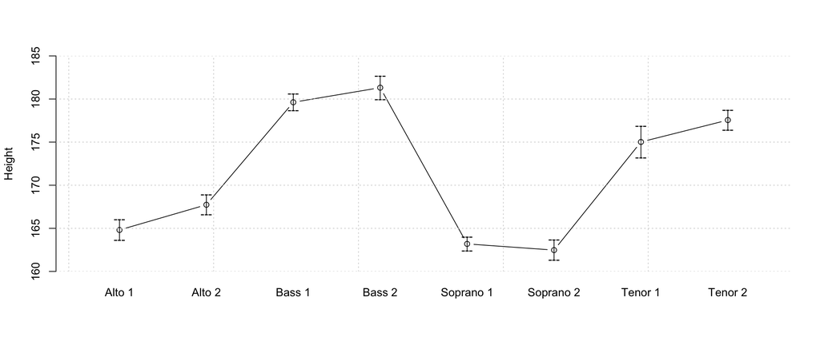

```r
bar.err(LSD1$means, variation="SE", bar=FALSE, col=0, ylim=c(160,185), ylab="Height")
grid()
```

HSD Тьюки:

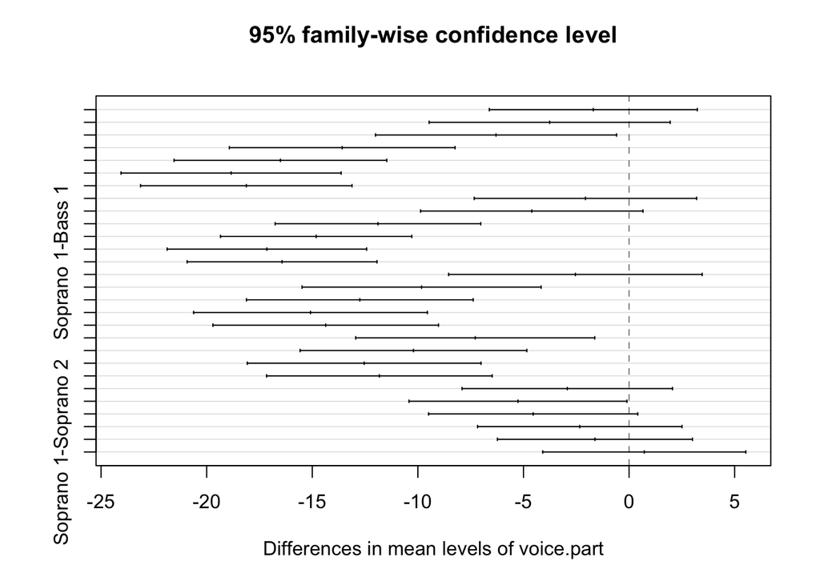

```r
tukey_hsd <- TukeyHSD(a1)
plot(tukey_hsd)
```

Критерий Неменьи:

```r
library(PMCMR)
posthoc.kruskal.nemenyi.test(x=singer$height, g=singer$voice.part, method="Tukey")
```

```
##
##  Pairwise comparisons using Tukey and Kramer (Nemenyi) test
##                    with Tukey-Dist approximation for independent samples
##
## data:  singer$height and singer$voice.part
##
##           Bass 2  Bass 1  Tenor 2 Tenor 1 Alto 2  Alto 1  Soprano 2
## Bass 1    0.99977 -       -       -       -       -       -
## Tenor 2   0.96962 0.99761 -       -       -       -       -
## Tenor 1   0.42605 0.61005 0.97477 -       -       -       -
## Alto 2    1.3e-05 1.2e-05 0.00495 0.13544 -       -       -
## Alto 1    4.3e-09 1.1e-09 2.5e-05 0.00374 0.96385 -       -
## Soprano 2 2.4e-11 4.0e-12 4.0e-07 0.00012 0.48000 0.96864 -
## Soprano 1 1.0e-11 1.1e-12 3.1e-07 0.00012 0.54417 0.98629 1.00000
##
## P value adjustment method: none
```

5. Предположим, что нас интересует, например, исключительно отличия между тенором 1 и всеми остальными голосами, можно было бы воспользоваться критерием Даннета. Для этого сделайте переупорядочивание значения фактора, начиная с `"Tenor 1"` с помощью функции `relevel`. Далее воспользуйтесь функцией `aov` и ее результат передайте в функцию `glht` пакета `multcomp`, передав в качестве параметра `linfct = mcp(voice.part = "Dunnett")`.

```r
singer$voice.part <- relevel(singer$voice.part, "Tenor 1")
a2  <- aov(height~voice.part, data=singer)

library(multcomp)
mcd <- glht(a2, linfct = mcp(voice.part = "Dunnett"))
summary(mcd)
```

```
##
##   Simultaneous Tests for General Linear Hypotheses
##
## Multiple Comparisons of Means: Dunnett Contrasts
##
##
## Fit: aov(formula = height ~ voice.part, data = singer)
##
## Linear Hypotheses:
##                          Estimate Std. Error t value Pr(>|t|)
## Bass 2 - Tenor 1 == 0       6.299      1.865   3.377  0.00507 **
## Bass 1 - Tenor 1 == 0       4.605      1.721   2.677  0.04112 *
## Tenor 2 - Tenor 1 == 0      2.540      1.962   1.295  0.61154
## Alto 2 - Tenor 1 == 0      -7.284      1.850  -3.938  < 0.001 ***
## Alto 1 - Tenor 1 == 0     -10.208      1.755  -5.818  < 0.001 ***
## Soprano 2 - Tenor 1 == 0  -12.543      1.809  -6.935  < 0.001 ***
## Soprano 1 - Tenor 1 == 0  -11.823      1.746  -6.773  < 0.001 ***
## ---
## Signif. codes:  0 '***' 0.001 '**' 0.01 '*' 0.05 '.' 0.1 ' ' 1
## (Adjusted p values reported -- single-step method)
```

```r
confint(mcd, level = 0.95)
```

```
##
##   Simultaneous Confidence Intervals
##
## Multiple Comparisons of Means: Dunnett Contrasts
##
##
## Fit: aov(formula = height ~ voice.part, data = singer)
##
## Quantile = 2.5998
## 95% family-wise confidence level
##
##
## Linear Hypotheses:
##                          Estimate lwr      upr
## Bass 2 - Tenor 1 == 0      6.2988   1.4499  11.1478
## Bass 1 - Tenor 1 == 0      4.6055   0.1322   9.0788
## Tenor 2 - Tenor 1 == 0     2.5400  -2.5604   7.6404
## Alto 2 - Tenor 1 == 0     -7.2840 -12.0927  -2.4753
## Alto 1 - Tenor 1 == 0    -10.2084 -14.7703  -5.6465
## Soprano 2 - Tenor 1 == 0 -12.5428 -17.2451  -7.8405
## Soprano 1 - Tenor 1 == 0 -11.8231 -16.3612  -7.2850
```

Также можно воспользоваться нисходящей модификацией этого критерия. Для этого передайте в функцию `summary` объект, полученный после применения функции `glht` и указав параметр `test = adjusted(type = "free")`. или его нисходящей модификацией:

```r
summary(mcd, test = adjusted(type = "free"))
```

```
##
##   Simultaneous Tests for General Linear Hypotheses
##
## Multiple Comparisons of Means: Dunnett Contrasts
##
##
## Fit: aov(formula = height ~ voice.part, data = singer)
##
## Linear Hypotheses:
##                          Estimate Std. Error t value Pr(>|t|)
## Bass 2 - Tenor 1 == 0       6.299      1.865   3.377 0.002394 **
## Bass 1 - Tenor 1 == 0       4.605      1.721   2.677 0.014932 *
## Tenor 2 - Tenor 1 == 0      2.540      1.962   1.295 0.196734
## Alto 2 - Tenor 1 == 0      -7.284      1.850  -3.938 0.000367 ***
## Alto 1 - Tenor 1 == 0     -10.208      1.755  -5.818 8.67e-08 ***
## Soprano 2 - Tenor 1 == 0  -12.543      1.809  -6.935 7.42e-11 ***
## Soprano 1 - Tenor 1 == 0  -11.823      1.746  -6.773 3.29e-10 ***
## ---
## Signif. codes:  0 '***' 0.001 '**' 0.01 '*' 0.05 '.' 0.1 ' ' 1
## (Adjusted p values reported -- free method)
```

Кроме того можно воспользоваться непараметрическим аналогом критерия Даннета с помощью функции `nparcomp` из пакета `nparcomp`. Для этого передайте в эту функцию последними параметрами строку `type = "Dunnett", asy.method = "mult.t", control = "Tenor 1", info = FALSE`. Функция `summary` вызыванная от объекта, который вернет функция `nparcomp`, вас приятно удивит обилием информации.

```r
library(nparcomp)
nmcd <- nparcomp(height~voice.part, data=singer, type = "Dunnett", asy.method = "mult.t", control = "Tenor 1", info = FALSE)
summary(nmcd)
```

```
##
##  #------------Nonparametric Multiple Comparisons for relative contrast effects----------#
##
##  - Alternative Hypothesis:  True relative contrast effect p is less or equal than 1/2
##  - Estimation Method: Global Pseudo ranks
##  - Type of Contrast : Dunnett
##  - Confidence Level: 95 %
##  - Method = Multi - T with 26 DF
##
##  - Estimation Method: Pairwise rankings
##
##  #---------------------------Interpretation--------------------------------------------#
##  p(a,b) > 1/2 : b tends to be larger than a
##  #-------------------------------------------------------------------------------------#
##
##  #----Data Info-------------------------------------------------------------------------#
##      Sample Size
## 1   Tenor 1   21
## 2    Bass 2   26
## 3    Bass 1   39
## 4   Tenor 2   21
## 5    Alto 2   27
## 6    Alto 1   35
## 7 Soprano 2   30
## 8 Soprano 1   36
##
##  #----Contrast--------------------------------------------------------------------------#
##                     Tenor 1 Bass 2 Bass 1 Tenor 2 Alto 2 Alto 1 Soprano 2
## Bass 2 - Tenor 1         -1      1      0       0      0      0         0
## Bass 1 - Tenor 1         -1      0      1       0      0      0         0
## Tenor 2 - Tenor 1        -1      0      0       1      0      0         0
## Alto 2 - Tenor 1         -1      0      0       0      1      0         0
## Alto 1 - Tenor 1         -1      0      0       0      0      1         0
## Soprano 2 - Tenor 1      -1      0      0       0      0      0         1
## Soprano 1 - Tenor 1      -1      0      0       0      0      0         0
##                     Soprano 1
## Bass 2 - Tenor 1            0
## Bass 1 - Tenor 1            0
## Tenor 2 - Tenor 1           0
## Alto 2 - Tenor 1            0
## Alto 1 - Tenor 1            0
## Soprano 2 - Tenor 1         0
## Soprano 1 - Tenor 1         1
##
##  #----Analysis--------------------------------------------------------------------------#
##                 Comparison Estimator  Lower Upper Statistic      p.Value
## 1    p( Tenor 1 , Bass 2 )     0.720  0.509 0.930  2.864109 3.823824e-02
## 2    p( Tenor 1 , Bass 1 )     0.673  0.453 0.894  2.156026 1.622067e-01
## 3   p( Tenor 1 , Tenor 2 )     0.609  0.353 0.865  1.164702 6.948438e-01
## 4    p( Tenor 1 , Alto 2 )     0.238  0.047 0.429 -3.751224 5.038847e-03
## 5    p( Tenor 1 , Alto 1 )     0.181  0.026 0.336 -5.628931 3.493235e-05
## 6 p( Tenor 1 , Soprano 2 )     0.117 -0.008 0.241 -8.439159 1.170499e-07
## 7 p( Tenor 1 , Soprano 1 )     0.108 -0.024 0.241 -8.105505 3.374937e-08
##
##  #----Overall---------------------------------------------------------------------------#
##   Quantile      p.Value
## 1 2.740723 3.374937e-08
##
##  #--------------------------------------------------------------------------------------#
```

Cleveland W. S. (1993) **Visualizing Data**. Summit, New Jersey: Hobart Press.